# R Tutorial Part 8: Final Task

# Final Task definition

The file “societies.csv” includes extra data about each society, including the geographic location (taken from D-PLACE, mainly based on Glottolog location data). The column `id` in societies.csv is an ID that can be matched to the column `society_id` in the main roof shape data.

Download societies.csv here: societies.csv. (https://github.com/seannyD/IntroToRForAnthropology/raw/main/data/societies.csv).

**Task**: Make a map of the world with a point added for each society, and where the colour of the point indicates whether it has a flat or non-flat roof. The map **should not** contain societies for which we don’t have rainfall data.

Write a script for this - don’t try and do it directly in the console.

Below is a set of steps you’ll need to take. Before looking at them, see if you can work these out yourself - braking the problem down is an important skill to develop.

You’ll need to:

- Download the “societies.csv” file and put it in your “data” folder.
- Load the roof, rainfall and society data
- Combine the data so that you have the roof shape, rainfall amount and geographic coordinates in one data frame. For the geographic coordinates, you might have to peek at the societies.csv data to figure out which column relates to the latitude and longitude.
- Filter out rows where the rainfall is NA.
- Create a new column in the dataframe which is either “Flat” or “Not Flat”.

Now we also need to assign a colour to each row, based on whether the rooves are flat or not flat.

- Create another new column `pointColour` in the main data that is e.g. “green” if the roof type is flat and “red” if the roof type is not flat.

Now we can draw the map:

- Draw a map
- Draw the points. The function `points` also has a `col` argument, where you can give it a vector which contains the colour for each point. You can put the `pointColour` data here.
- Add some code to write the map to a file

Here’s my plot, with a legend for reference. Click on the `code` button to the right to reveal one possible answer.

[output not shown]

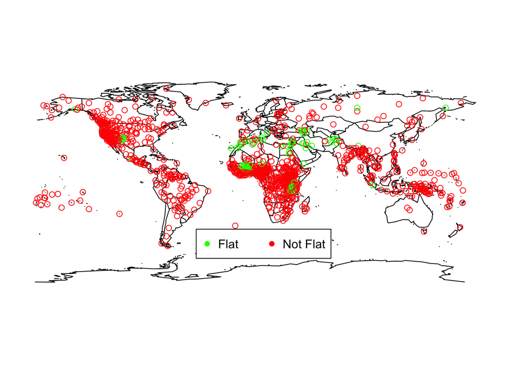

```r
# Set the working directory
setwd("~/Documents/Teaching/CARDIFF/RCourse/IntroToRForAnthropologists/analysis/")

# Load the maps library
library(maps)

#Load the roof data
d = read.csv("../data/RoofShapeData.csv", stringsAsFactors = F)
# Creae a variable called 'roofShape', just for convenience
d$roofShape <- d$code_label
# Work out flat/ non-flat

d$flatRoof = d$roofShape == "Flat"

# Load rainfall data
rainfallData = read.csv("../data/RainfallData_all.csv",stringsAsFactors = F)

# Add the rainfall data into the main data source
d$rainfall <- rainfallData[match(d$society_id, rainfallData$society_id) , ]$code

# Filter out any data with NA values in rainfall
d = d[!is.na(d$rainfall),]

# Load society data
societyData = read.csv("../data/societies.csv",stringsAsFactors = F)

# Add the geographic coordinates
d$longitude <- societyData[match(d$society_id, societyData$id) , ]$Long
d$latitude <- societyData[match(d$society_id, societyData$id) , ]$Lat

# Assign a colour based on the roof shape
# First, we just create a new variable that is "red" for all rows:
d$pointColour = "red"
# Now we set any rows where the roof shape is flat to "green":
#    (remember that 'flatRoof' is a boolean vector)
d[d$flatRoof,]$pointColour = "green"

# Create a new pdf file
pdf("myMap.pdf", width=15, height=10)
  # draw a map
  map()
  # add points
  points(d$longitude, d$latitude, col= d$pointColour)
  # add a legend
  legend(-45,-40, legend=c("Flat","Not Flat"),
         col=c("green","red"), pch=16, ncol=2)
# We're done with plotting, so close the file connection
dev.off()
```

Back to the index